# Topic Breakdown and Sentiment Analysis of Executive Orders from 2009 to 2025

Text Analysis Project Showcase · November 3, 2026

Author

Eleanor Dowhower · POLS 4130 · Fall 2026

## Question

What topic has the highest salience overall and what is the average sentiment towards the topic?

### Data

I chose to examine U.S. executive orders from 2009 to 2025 , 658 documents with each row representing 1 executive order.

### Methods

**Sentiment:** Using the Bing Liu Lexicon, I summed matched values within each executive order and averaged the score by administration. Executive Orders under the Obama administration had a mean coverage of 0.0365, executive Orders under the first Trump administration had a mean coverage of 0.422, and executive Orders under the Biden administration had a mean coverage of 0.415.

**Topics:** First I separated the words within each document into tokens. I also discarded numeric values within the text because they are not relevant in determining the topics within executive orders. I then lemmatized the words to ensure R detects one word regardless of inflections, thus preventing them from appearing multiple times in different forms. I then filtered out stop words within the SMART lexicon to discard words that do not indicate the substance of a document. I added the extra stop words “executive”, “order”, “state”, “agency”, “section”, “unite”, “law”, “secretary”, “department”, and “amend.” After experimenting with plots and reading the texts, I found that many documents shared the same procedural words indicating nothing about the subject matter. For example, many documents began with similar preambles stating the president’s authority to enact an executive order or amend existing orders. I removed the rest of the words similarly because they did not relate to specific topics; rather, they related to the general role and function of executive orders as a means of policy enforcement. I chose to sort the documents into 5 categories and increase the top words to 15 due to the size and scope of the data set. 658 documents retained words for modeling. After generating a plot to visualize top words by topic, I checked the keywords against the texts and confirmed their accuracy. Using full texts and keywords, I determined 5 topic labels.

## Frequency Finding

Across all executive orders between 2009 and 2025, the most frequent word was federal.

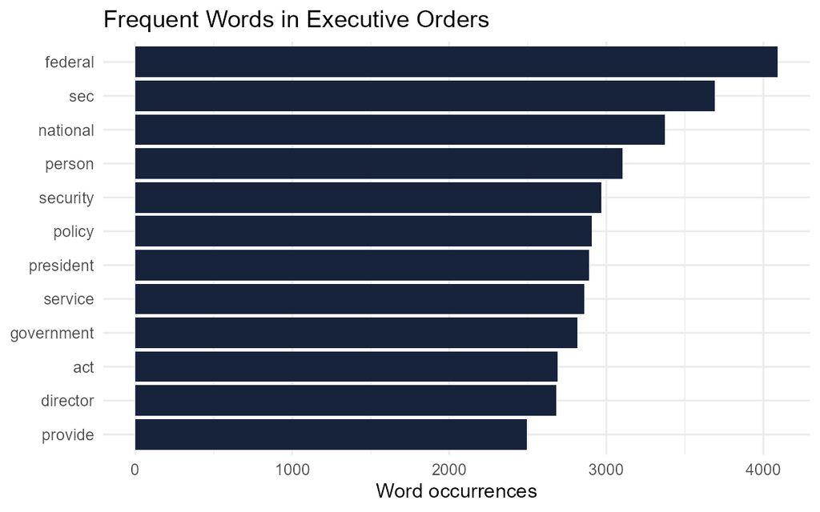

[interactive chart not shown]

## Sentiment finding

Biden had the most positive dictionary score between the three administrations.

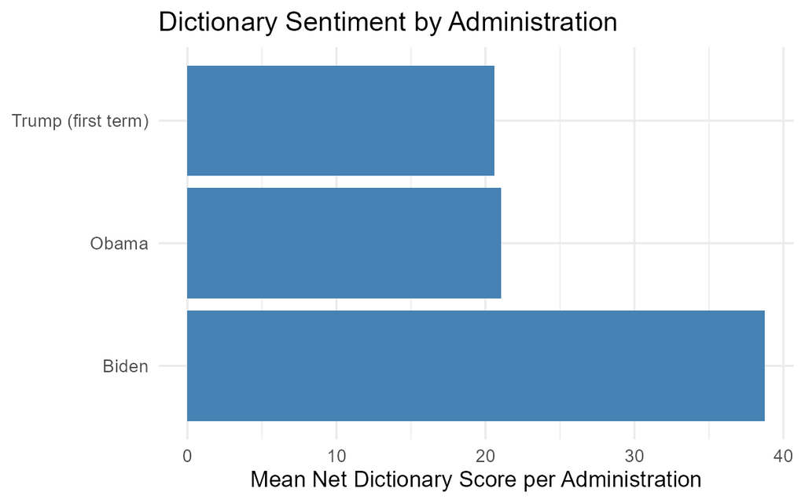

Mean Sentiment Score of all Executive Orders Sorted by Administration.

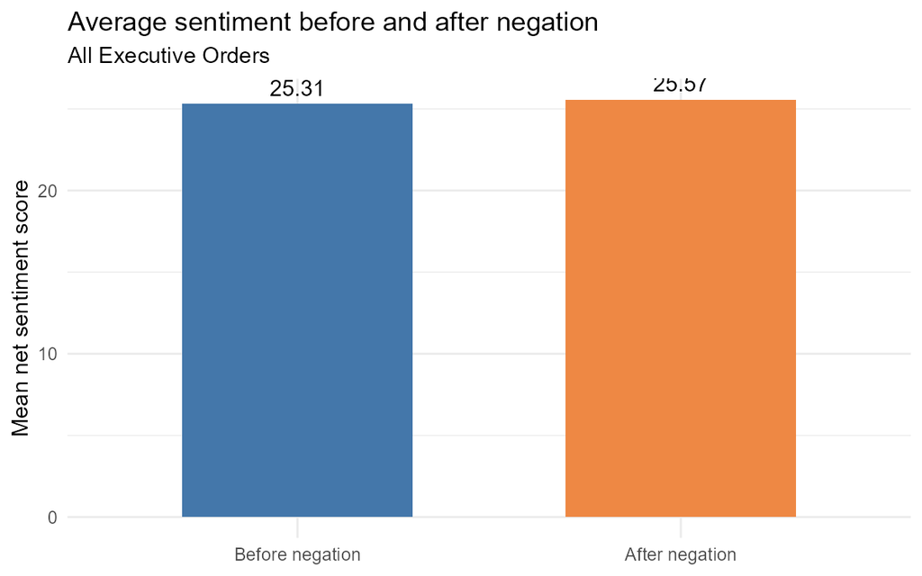

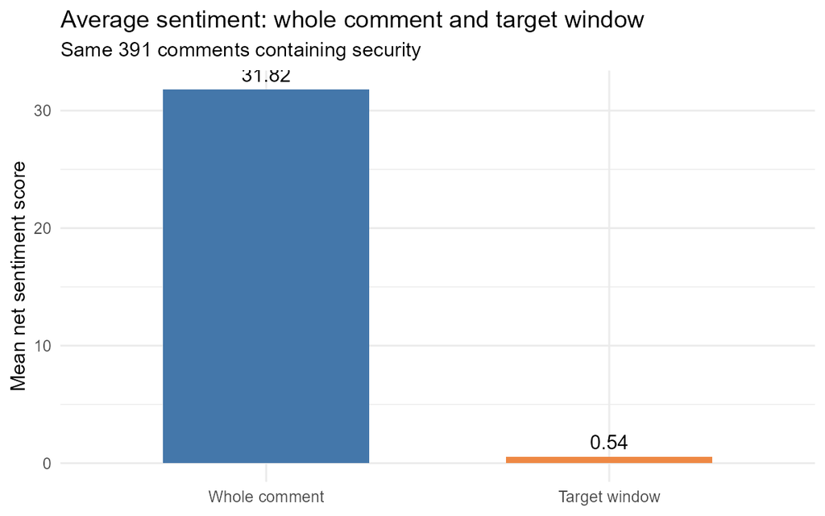

## Topic finding

The topic with the highest proportion of executive orders was national security.

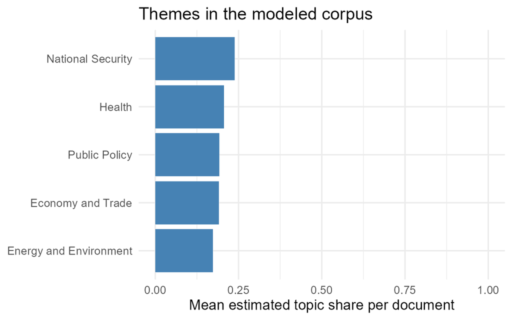

5 main topics within executive orders and the most frequent words within them.

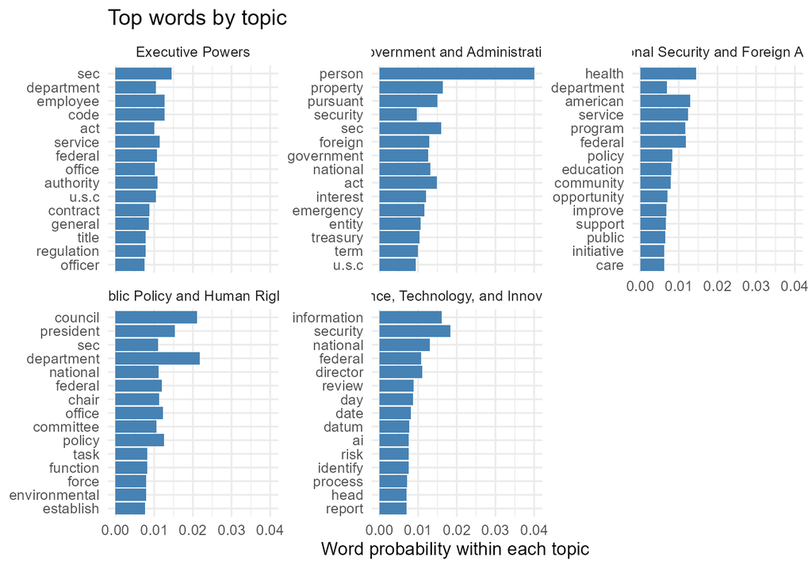

Sentiments towards each topic

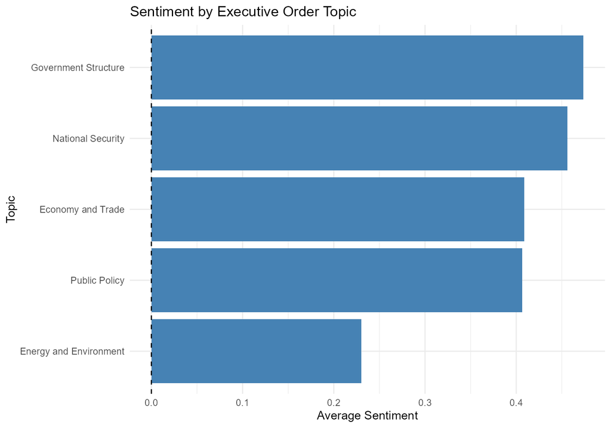

## Analysis of Individual Documents

**Sentiment:** The following document had a net sentiment score of 50: “Executive Order 13602 of March 15, 2012 Establishing a White House Council on Strong Cities, Strong Communities By the authority vested in me as President by the Constitution and the laws of the United States of America, and in order to forge a partnership with local communities to provide them with comprehensive technical assistance to use and compete for Federal resources more effectively and efficiently, which will enable them to develop and implement economic strategies to become more competitive, sustainable, and inclusive, it is hereby ordered as follows: Section 1. Policy. Cities, towns, and regions across our Nation continue to face difficult economic challenges. Enhancing current Federal assistance is helping to lift communities out of distress. To allow the Federal Government to better partner with these local communities to build local capacity to address economic issues, and to support comprehensive planning and regional collaboration, my Administration established the Strong Cities, Strong Communities (SC2) pilot initiative. By partnering with cities and regions to augment their vision for stability and economic growth, the SC2 was designed to help communities strengthen their capacity to create jobs and more competitive business climates, and implement locally driven community and regional planning approaches that lead to sustained economic growth, as well as ensure that Federal assistance is more efficiently provided and used. This order improves the way the Federal Government engages with and supports local communities by better aligning resources and coordinating efforts across executive departments and agencies (agencies) so that communities across the country have access to comprehensive, localized technical assistance and planning resources to develop and implement their economic vision and strategies. Sec. 2. White House Council on Strong Cities, Strong Communities” (id=114).

I believe the score of 50 is accurate as the order focuses on future actions and uses an affirmative tone rather than focusing on underlying issues or phrasing actions in the negative.

**Topics:**

*Executive Power - id: 114* “Executive Order 13602 of March 15, 2012 Establishing a White House Council on Strong Cities, Strong Communities By the authority vested in me as President by the Constitution and the laws of the United States of America, and in order to forge a partnership with local communities to provide them with comprehensive technical assistance to use and compete for Federal resources more effectively and efficiently, which will enable them to develop and implement economic strategies to become more competitive, sustainable, and inclusive, it is hereby ordered as follows:” - Authority - Federal - President - Department

*Government Operations and Structure - id: 646* “Executive Order 14134 of January 3, 2025 Providing an Order of Succession Within the Department of Agriculture By the authority vested in me as President by the Constitution and the laws of the United States of America, including the Federal Vacancies Reform Act of 1998, as amended, 5 U.S.C. 3345 et seq . (the “Act”), it is hereby ordered that: Section 1 . Order of Succession . (a) Subject to the provisions of section 2 of this order, and to the limitations set forth in the Act, the following officials of the Department of Agriculture, in the order listed, shall act as and perform the functions and duties of the office of Secretary of Agriculture (Secretary) during any period in which both the Secretary and the Deputy Secretary of Agriculture have died, resigned, or otherwise become unable to perform the functions and duties of the office of Secretary:” - Department - Sec - office - Authority

*National Security and Foreign Affairs - id: 595* “Executive Order 14083 of September 15, 2022 Ensuring Robust Consideration of Evolving National Security Risks by the Committee on Foreign Investment in the United States By the authority vested in me as President by the Constitution and the laws of the United States of America, including section 721 of the Defense Production Act of 1950, as amended ( 50 U.S.C. 4565 ) (section 721), and section 301 of title 3, United States Code , it is hereby ordered as follows: Section 1 . Policy. The United States welcomes and supports foreign investment, consistent with the protection of national security.” - Foreign - Security - National

*Public Policy and Civil Rights- id: 553* “Executive Order 14041 of September 3, 2021 White House Initiative on Advancing Educational Equity, Excellence, and Economic Opportunity Through Historically Black Colleges and Universities By the authority vested in me as President by the Constitution and the laws of the United States of America, and in order to advance equity in economic and educational opportunities for all Americans, including Black Americans, strengthen the capacity of Historically Black Colleges and Universities (HBCUs) to provide the highest-quality education, increase opportunities for these institutions to participate in and benefit from Federal programs, and ensure that HBCUs can continue to be engines of opportunity, it is hereby ordered as follows: Section 1 . Policy . HBCUs have a proud history and legacy of achievement. In the face of discrimination against Black Americans by many institutions of higher education, HBCUs created pathways to opportunity and educational excellence for Black students throughout our Nation.” - Federal - Program - Policy - Education - Opportunity

### Limits

**Sentiment:** The Dictionary may attach positive or negative meaning to words that are used differently in the data-set. For example, the dictionary defines trump as a positive, meaning any mention of Trump as a name count as a positive; however, this issue can be fixed by filtering out Trump.

**Topics:** Often executive orders are relevant in multiple areas. For example, I noticed National Security overlapped often with topics like technology, government operations, or executive structure.

### Significance of Analysis Methods

Topic modeling and sentiment analysis help examine both a topic’s salience and the general sentiment towards it. Here I found that National Security had the highest salience and is spoken about relatively neutrally. After inspecting individual texts within the topic, I observed that most focused on action rather than describing an issue and its negative impacts. They often center on solving problems instead of dwelling on the problems themselves. The neutrality tended to result from lack of negative or positive word matches rather than a balanced number of positive and negative words.

**Sources:** Corpus: US Executive Orders between 2009 and 2025. Sentiment dictionary: Hu, M., & Liu, B. (2004). Mining and summarizing customer reviews. Proceedings of the ACM SIGKDD International Conference on Knowledge Discovery & Data Mining (KDD-2004), 168–177. doi.org